# DATA612_Project 5 | IMPLEMENTING A RECOMMENDER SYSTEM ON SPARK

Amber Ferger, Charlie Rosemond, Juanelle Marks

6/14/2020

## Assignment

The goal of this project is give you practice beginning to work with a distributed recommender system. It is sufficient for this assignment to build out your application on a single node.

Adapt one of your recommendation systems to work with Apache Spark and compare the performance with your previous iteration. Consider the efficiency of the system and the added complexity of using Spark. You may complete the assignment using PySpark (Python), SparkR (R) , sparklyr (R), or Scala.

Please include in your conclusion: For your given recommender system’s data, algorithm(s), and (envisioned) implementation, at what point would you see moving to a distributed platform such as Spark becoming necessary?

You may work on any platform of your choosing, including Databricks Community Edition or in local mode. You are encouraged but not required to work in a small group on this project.

## Motivation

In this assignment, we create two alternating least squares (ALS) recommenders–one with *recommenderlab* and one with Apache Spark via *sparklyr*–and compare their performance. Our goal is to gain experience with Spark and begin to assess its advantages over a non-distributed platform.

## Data

Our data source is the [Jester](http://eigentaste.berkeley.edu/dataset/) dataset, which contains data from 24,983 users who have rated 36 or more jokes. Ratings are real values ranging from -10.00 to +10.00 (the value “99” corresponds to “null” = “not rated”). Each row in the dataset represents a different user, and the first column represents the total number of jokes the individual has rated. The remaining 100 columns give the ratings for each joke.

### Load libraries

### Read and prepare data

```r
# Read jester data
jester <- data.frame(read_xls("jester-data-1.xls", col_names = FALSE))
colnames(jester) <- c("ratingCount", seq(100))
row.names(jester) <- 1:nrow(jester)

# Remove num jokes column
ratings <- jester[-1]

# Replace 99 (no rating) with NA
ratings[ratings == 99] <- NA

# Subset to first 5000 users
ratings <- ratings[1:5000,]

# Create user- and item-specific counts
jokeCount <- rowSums(!is.na(ratings))
ratingCount <- colSums(!is.na(ratings))

# Function to replace NA with column medians
medValue.f <- function(x){
   x[is.na(x)] = median(x, na.rm=TRUE)
   return(x)
}
ratings_impute <- apply(ratings, 2, medValue.f)

# Create large dgCMatrix
ratings_matrix <- as.matrix(ratings_impute)
recclab_ratings <- as(ratings_matrix, 'realRatingMatrix')
```

## Exploratory data analysis

First, we explore the data prior to imputation.

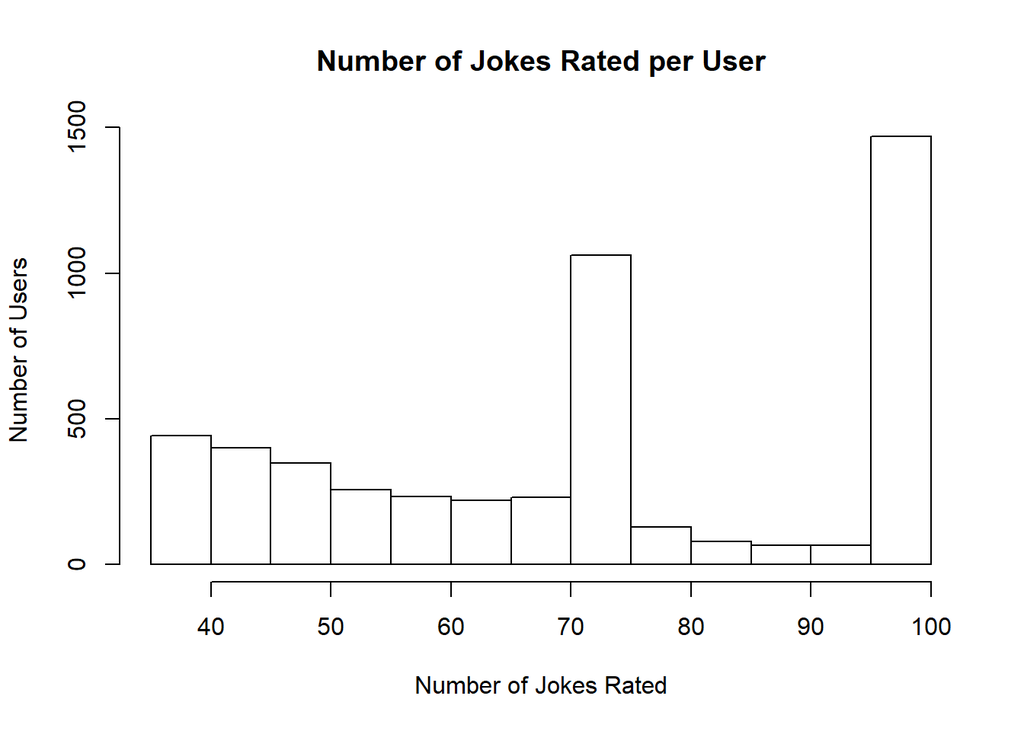

```r
hist(jokeCount,
     main = 'Number of Jokes Rated per User',
     xlab = 'Number of Jokes Rated',
     ylab = 'Number of Users')
```

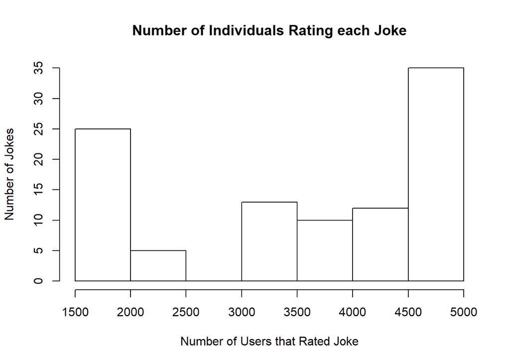

```r
hist(ratingCount,
     main = 'Number of Individuals Rating each Joke',
     xlab = 'Number of Users that Rated Joke',
     ylab = 'Number of Jokes')
```

```r
# Mean and median joke rating
(mean(as.matrix(ratings), na.rm = TRUE))
```

```
## [1] 0.8902123
```

```r
(median(as.matrix(ratings), na.rm = TRUE))
```

```
## [1] 1.5
```

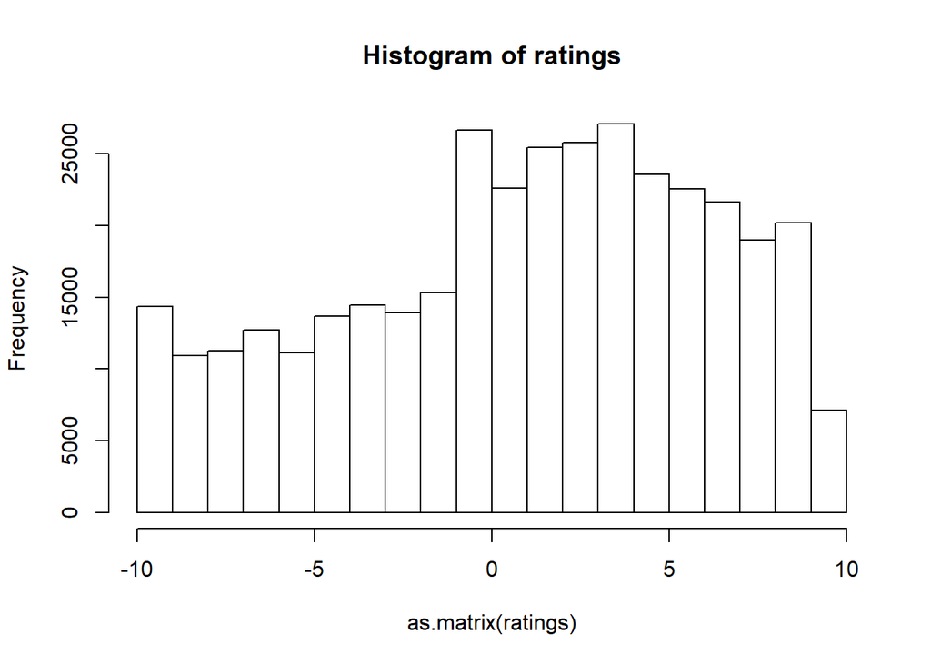

```r
# Histogram of ratings
hist(as.matrix(ratings), main = "Histogram of ratings")
```

## Recommenders

We compare ALS recommenders built using *recommenderlab* and Spark via *sparklyr*.

### recommenderlab

We start with *recommenderlab*. We split the ratings matrix into train (0.8) and test (0.2) sets; for test users, give 15 joke items; and set a good rating as 2 given the mean and median.

```r
# Defining an evaluation scheme
set.seed(612)
trainPct <- 0.8
toKeep <- 15
ratingThreshold <- 2
# define evaluation scheme
e <- evaluationScheme(recclab_ratings, method = "split", train = trainPct, given = toKeep, goodRating = ratingThreshold)
```

```r
recclab_recc <- Recommender(getData(e, "train"), method = "ALS", param = list(n_factors = 10, lambda = 0.1, n_iterations = 10, seed = 612))
```

```r
start <- Sys.time()
recclab_pred <- predict(recclab_recc, getData(e, "known"), type="ratings")
stop <- Sys.time()
```

```r
(recclab_error <- calcPredictionAccuracy(recclab_pred, getData(e, "unknown")))
```

```
##      RMSE       MSE       MAE
##  4.382432 19.205711  3.115437
```

```r
(recclab_time <- stop - start)
```

```
## Time difference of 5.254346 mins
```

### sparklyr

Next, we move to Spark and *sparklyr*. We start by restructuring the ratings data to facilitate modeling.

```r
ratings_df <- as.data.frame(ratings_impute)
```

```r
ratings_df$user <- 1:nrow(ratings_df)
ratings_df <- ratings_df %>% gather("item", "rating", -user)
ratings_df$item <- as.numeric(ratings_df$item)
ratings_df$rating <- as.numeric(ratings_df$rating)
ratings_df <- arrange(ratings_df, user, item)
```

Our work in Spark starts with establishing a local connection.

```r
sc <- spark_connect(master = "local", spark_home = "C:\\Spark\\spark-2.4.6-bin-hadoop2.7")
```

We create a tbl_spark object containing the long ratings dataframe.

```r
sparklyr_ratings <- sdf_copy_to(sc, ratings_df)
```

Next, we build then make predictions using an ALS recommender with parameters that mirror those of the model built with *recommenderlab*.

```r
sparklyr_recc <- ml_als(sparklyr_ratings, rating_col = "rating", user_col = "user", item_col = "item", rank = 10, reg_param = 0.1, max_iter = 10)
```

```r
start <- Sys.time()
sparklyr_pred <- ml_predict(sparklyr_recc, sparklyr_ratings)
stop <- Sys.time()
```

```r
sparklyr_df <- as.data.frame(sparklyr_pred)
(sparklyr_error = c(
  "RMSE" = RMSE(sparklyr_df$rating, sparklyr_df$prediction),
  "MSE" = MSE(sparklyr_df$rating, sparklyr_df$prediction),
  "MAE" = MAE(sparklyr_df$rating, sparklyr_df$prediction)
  )
)
```

```
##     RMSE      MSE      MAE
## 3.155573 9.957642 2.253420
```

```r
(sparklyr_time <- stop - start)
```

```
## Time difference of 0.1447399 secs
```

```r
spark_disconnect(sc)
```

## Reference